# WDS, HW 2

Aaron

Neil

Ben

Luke

Tanvi

Due: 10:00PM, Friday, July 16, 2021

# Objectives

*The main purpose for this homework is to tell the difference between probability and statistics.* Using the Roulette game as illustration, we go through the main elements of probability and statstics. We then learn how to estimate unknown parameters in a population with precision, i.e., a confidence interval. Simulations help us to understand the interpretation of a confidence interval.

- Continue to get used to `RStudio` and `RMarkdown`
- Probability
  - Random variables and their distributions
  - Population parameters: expected values and variances
  - Normal variables
  - Central limit theorem (CLT)
- Statistics
  - Sample means and sample variances
  - Use sample mean to estimate the population mean
  - Confidence intervals/hypothesis tests
- Packages/functions
  - `dplyr`
  - `ggplot`
  - `pnorm()`, `qnorm()`, `dnorm()`

# Review materials

- Study Module 2: Probability_Statistics_101

# Question 1: Probability

The following questions refer to the Red-Black Roulette game. After the ball is spun it will land in one of the slots.

1. What is the probability that the ball will land in any one slot?

The probability a ball will land on a specific spot is a 1 in 38 chance.

2. A player will bet $1 each time. Let $X$ be the payoff.
   1. If the player bets on a single number, write down the distribution of $X$, i.e. the possible values of $X$ and the corresponding probabilities. Calculate the expected value of winning and the standard deviation.

```r
  expected_1 <- 1/38*35 + 37/38*-1
  variance_1 <- (35-(-0.0526))^2 * 1/38 + (-1 -(-0.0526))^2 * 37/38
  standard_1 <- sqrt(variance_1)
```

```
(ii)    Repeat number (i) if the player bets on two numbers.
```

```r
  expected_2 <- 2/38*35 + 36/38*-1
  variance_2 <- (35-(-0.0526))^2 * 2/38 + (-1 -(-0.0526))^2 * 36/38
  standard_2 <- sqrt(variance_2)
```

```
(iii)   If one plays the game by betting on a single number 1000 times, how much do you expect the person to win?
```

```r
# expected gain


n <- 1000
win_prob <- 1/38
# winning event
set.seed(2021)
win_vec <- rbinom(n,1,win_prob)
# if win: +35; if lose: -1
gain_vec <- win_vec*36
gain_vec <- gain_vec-1
# print first 100 gains
# head(gain_vec, 100)
# to find average gain
sum(gain_vec)
```

```
## [1] 8
```

According to our seed simulation, we would expect the person to win $8.

```
(iv)    Explain now why the casinos always make money on the roulette game.
```

Casinos always make money on the roulette game because no matter what way you position yourself- all black, all red, or a specific number, the casino is favored to win. The highest probability you could give yourself is 18/38, and that in itself is not above 50%, making the results biased towards the casino. Taking into account the concept of expected value, as the amount of games increases, the more likely you are to approach that value- thus the casinos are extremely likely make money on the roulette game as the number of trials approach larger and larger numbers.

3. Let’s “play” the game using code.
   1. We bet 30 times each round. Put 30 payoffs into a vector and store into a variable.

```r
set.seed(1)
num_win = rbinom(30, 30, 1/36)
num_win
```

```
##  [1] 0 0 1 2 0 2 2 1 1 0 0 0 1 0 1 1 1 4 0 1 2 0 1 0 0 0 0 0 2 0
```

2. Plot the histogram of the 30 payoffs. What is the total payoffs for this round?

[figure not shown]

```
(iii) Let's play another 100 rounds. Plot the histogram of total payoffs. What is the average payoff from these 100 rounds? Is this as expected?
```

```r
num_lose <- 30- num_win
avg_gain <-  (num_win - num_lose)/30
hist(avg_gain)
```

[output not shown]

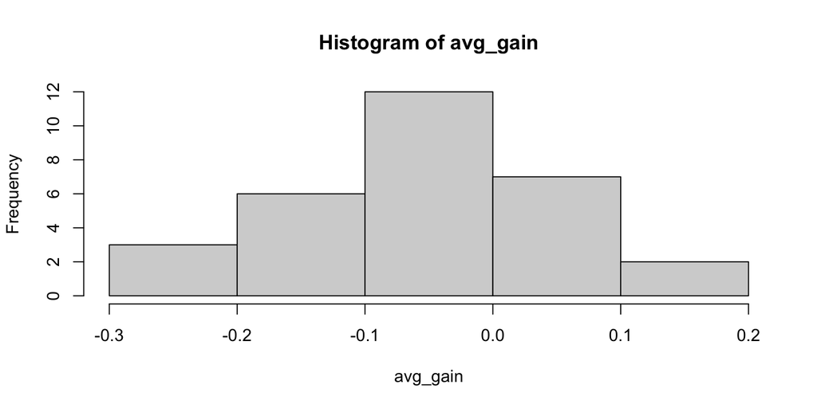

```r
set.seed(1)

num_win <- rbinom(30, 100, 18/38)
num_lose <- 100 - num_win

avg_gain <-  (num_win - num_lose)/100

hist(avg_gain)
```

# Question 2: Statistics

This exercise is designed to help you understand the notion of confidence interval and understand confidence interval through simulations.

Let $Y$ be the average winning amount among 100 games of betting $1 each time in the Red-Black Roulette game. We know that $Y$ follows approximately a normal distribution with mean $\mu = -.0526$ and standard deviation $\sigma = .1$. We will start to record the game payoff each time but pretend that we do not know the true mean is -.0526.

1. Generate 50 $Y's$ from $N(\mu = -.0526, \sigma =.1)$ with `set.seed(1)`. Construct a $95\%$ confidence interval for the unknown mean. State the confidence interval. Is the true value -.0526 inside the confidence interval?

The true value -.0526 is inside the confidence interval.

```r
set.seed(1)
n_sim <- 50 # number of simulations
mu_hat <- numeric(n_sim)   # estimate
upper_ci <- numeric(n_sim)  # lower bound
lower_ci <- numeric(n_sim)  # upper bound

# Carry out the simulation
for (i in 1:n_sim){
  y <- rnorm(50, mean= -.0526, sd = .1)
  mu_hat <- mean(y)
  mu_sd <- sd(y)
  lower_ci[i] <- mu_hat - (2*mu_sd)/sqrt(50)
  upper_ci[i] <- mu_hat + (2*mu_sd)/sqrt(50)
}

answer <- (lower_ci < -.0526) & (upper_ci > -.0526)
sum(answer)
```

```
## [1] 48
```

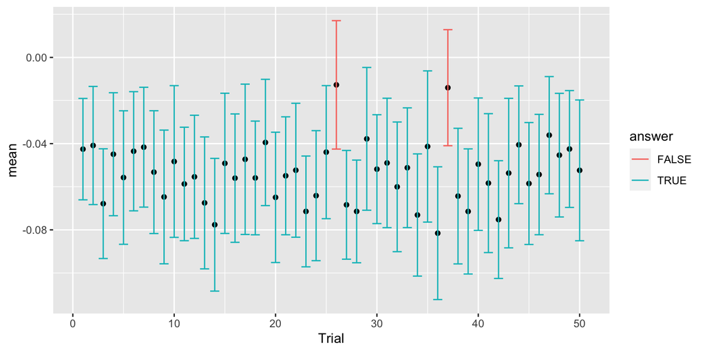

```r
results <- cbind(lower_ci, upper_ci)

ci_df <- data.frame(
  id = 1:n_sim,
  lower_ci = lower_ci,
  upper_ci = upper_ci)

ggplot(ci_df,aes(x = id, y = (lower_ci + upper_ci)/2)) +
  geom_point() +
  geom_errorbar(aes(ymax = upper_ci, ymin = lower_ci, color = answer)) +
  labs(x = "Trial", y = "mean")
```

2. Repeat question 2a. 100 times to generate 100 samples (each has sample size 50 and follows $N(\mu = -.0526, \sigma =.1)$) and produce 100 95% confidence intervals. How many of the confidence intervals capture the true mean -.0526? Display your 100 confidence intervals in a meaningful way.

```r
set.seed(1)
n_sim <- 100 # number of simulations
mu_hat <- numeric(n_sim)   # estimate
upper_ci <- numeric(n_sim)  # lower bound
lower_ci <- numeric(n_sim)  # upper bound

# Carry out the simulation
for (i in 1:n_sim){
  y <- rnorm(50, mean= -.0526, sd = .1)
  mu_hat <- mean(y)
  mu_sd <- sd(y)
  lower_ci[i] <- mu_hat - (2*mu_sd)/sqrt(50)
  upper_ci[i] <- mu_hat + (2*mu_sd)/sqrt(50)
}

answer <- (lower_ci < -.0526) & (upper_ci > -.0526)
sum(answer)
```

```
## [1] 97
```

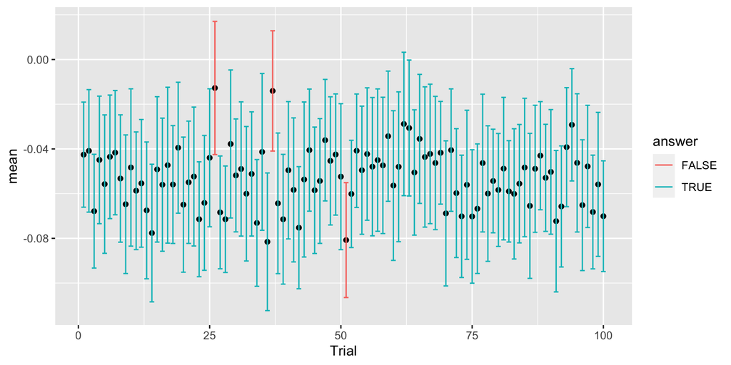

```r
results <- cbind(lower_ci, upper_ci)

ci_df <- data.frame(
  id = 1:n_sim,
  lower_ci = lower_ci,
  upper_ci = upper_ci)

ggplot(ci_df,aes(x = id, y = (lower_ci + upper_ci)/2)) +
  geom_point() +
  geom_errorbar(aes(ymax = upper_ci, ymin = lower_ci, color = answer)) +
  labs(x = "Trial", y = "mean")
```

3. Summarize the interpretation of a 95% confidence interval based on the simulation in question 2b.  
   The interpretation of a 95% confidence interval based on the simulation is essentially that 95% of the data captures the true mean of our expected game winnings, while 5% of the data is not representative of true mean. In this case, out of this simulation, 3 out of the 100 trials turned out to be not within the bounds of our confidence interval, but we were still able to maintain the 95% confidence interval. It turns out that we were 97% accurate, for this specific simulation and seed.